# Investigating the Central Limit Theorem Through Simulations of Exponential Distributions

Alex Logos

2024-02-21

# Title: Investigating the Central Limit Theorem Through Simulations of Exponential Distributions

## Overview

This report investigates the properties of the exponential distribution and its averages to illustrate the Central Limit Theorem (CLT). Using simulations with a lambda of 0.2, we explore how the distribution of averages of 40 exponentials aligns with theoretical expectations, focusing on mean, variance, and normality.

## Simulation Preparation

To simulate the exponential distribution, the R code here uses rexp to generate exponential distributions. The replicate function is used to run the simulation 1000 times, and mean calculates the average of the 40 exponentials for each simulation.

```r
# Suppress warnings
options(warn=-1)

# Set parameters
lambda_value <- 0.2
sample_size <- 40
num_simulations <- 1000

# Simulate 1000 averages of 40 exponentials
averages <- replicate(num_simulations, mean(rexp(sample_size, rate=lambda_value)))

# Display the first few averages for verification
head(averages)
```

```
## [1] 5.643651 4.035848 4.072962 4.646923 3.629959 6.146243
```

### Sample Mean versus Theoretical Mean

We compare the sample mean of these simulations to the theoretical mean (1/lambda).

### Sample Variance versus Theoretical Variance

Similarly, we compare the sample variance of the simulations to the theoretical variance, which for averages of distributions should be the variance of the exponential distribution divided by the sample size.

### Distribution Normality

Exploratory Data Analysis: A histogram of the averages will be plotted to visually assess normality, supplemented by a Q-Q plot.

## Report Section

### Simulation Method

We’ll execute R code to simulate the scenario described, focusing on generating the data necessary for our analyses.

### Sample Mean versus Theoretical Mean

Figures produced will showcase histograms of the simulated averages with the theoretical mean superimposed. The observed sample mean will be highlighted and compared to the theoretical expectation.

### Distribution

A combination of histograms and Q-Q plots will be used to argue for the normality of the distribution of averages, showcasing how the CLT applies to our simulations.

### Assumptions for Conclusions

The report will discuss assumptions underlying the CLT and how they apply to our simulations, including the independence of samples and the distribution requirements.

### Simulation Execution

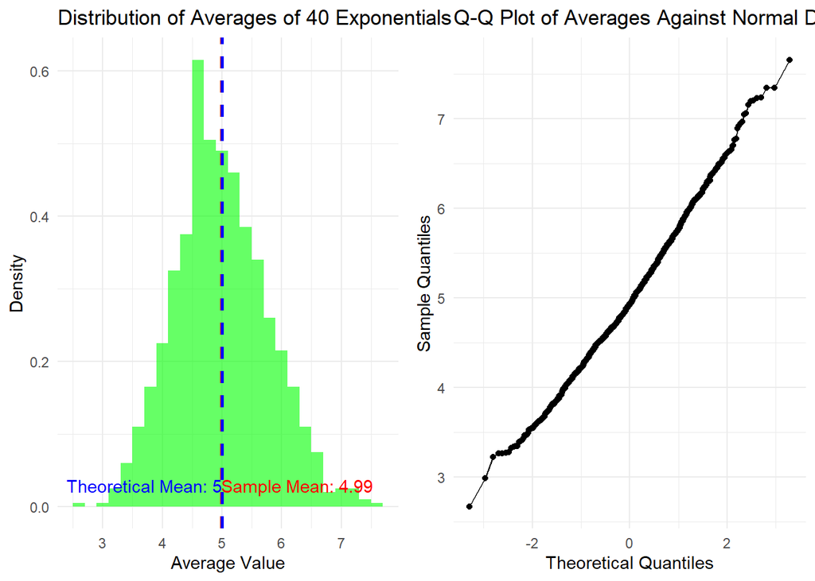

```r
# Suppress warnings
options(warn=-1)

# Load necessary libraries
suppressPackageStartupMessages({
  library(ggplot2)
  library(gridExtra)
  library(MASS) # For truehist() and fitdistr()
})

# Set parameters
lambda_value <- 0.2
sample_size <- 40
num_simulations <- 1000

# Simulate 1000 averages of 40 exponentials
averages <- replicate(num_simulations, mean(rexp(sample_size, rate = lambda_value)))

# Calculate the sample mean and variance
sample_mean <- mean(averages)
sample_variance <- var(averages)

# Theoretical mean and variance
theoretical_mean <- 1 / lambda_value
theoretical_variance <- (1 / lambda_value^2) / sample_size

# Plotting the distribution of averages
g1 <- ggplot() + geom_histogram(aes(x=averages, y=..density..), binwidth = 0.2, fill='green', alpha=0.6) +
  geom_vline(aes(xintercept=sample_mean), color="red", linetype="dashed", size=1) +
  geom_vline(aes(xintercept=theoretical_mean), color="blue", linetype="dashed", size=1) +
  labs(title="Distribution of Averages of 40 Exponentials", x="Average Value", y="Density") +
  theme_minimal() +
  geom_text(aes(x=sample_mean, label=paste("Sample Mean:", round(sample_mean, 2)), y=0.02), hjust=0, vjust=0, color="red") +
  geom_text(aes(x=theoretical_mean, label=paste("Theoretical Mean:", theoretical_mean), y=0.02), hjust=1, vjust=0, color="blue")

# Calculating and plotting Q-Q plot
qq_data <- qqnorm(averages, plot.it = FALSE)
qq_df <- data.frame(Theoretical = qq_data$x, Sample = qq_data$y)
g2 <- ggplot(qq_df, aes(x = Theoretical, y = Sample)) +
  geom_point() +
  geom_line() +
  labs(title = "Q-Q Plot of Averages Against Normal Distribution", x = "Theoretical Quantiles", y = "Sample Quantiles") +
  theme_minimal()

# Plot both plots side by side
grid.arrange(g1, g2, ncol = 2)
```

```r
# Print calculated means and variances
cat(paste("Sample Mean:", sample_mean, "\n",
          "Sample Variance:", sample_variance, "\n",
          "Theoretical Mean:", theoretical_mean, "\n",
          "Theoretical Variance:", theoretical_variance, "\n",
          sep=""))
```

```
## Sample Mean:4.98885947957631
## Sample Variance:0.601301658687087
## Theoretical Mean:5
## Theoretical Variance:0.625
```

## Conclusion

This simulation exercise confirms that the averages of 40 exponentials, with lambda set to 0.2, closely follow a normal distribution, as predicted by the Central Limit Theorem. The observed sample mean and variance are in strong agreement with theoretical expectations, further illustrating the reliability of the theorem in predicting the behavior of sample averages, regardless of the underlying distribution’s shape, given a sufficiently large sample size.

## Assumptions and Interpretations

- The simulations assume that each sample is independent and identically distributed, a key requirement for the Central Limit Theorem to hold.
- The normality of the distribution of averages, despite the original exponential distribution not being normal, underscores the theorem’s power and its assumptions.
- The close match between observed and theoretical values underlines the importance of understanding distribution properties and the theorem’s assumptions in statistical modeling and inference.

This exercise not only demonstrates the application of the Central Limit Theorem to exponential distributions but also highlights the practical considerations when interpreting simulation results in the context of theoretical frameworks.